# Descent Computation

Giampino Alice; Nardelli Vincenzo

22/7/2020

With the gradient package is possible to fit linear models using steepest descent or gradient discent with the same flexibility of the default function in R. First of all we load the library.

```r
library(gradient)
```

In this example we will use a generated dataset but it is possible to use real data too. Moreover we initialize some parameter that will be used in the following functions.

```r
n = 10000
x1 = rnorm(n)
x2 = rnorm(n)

y = 1 + .5*x1 + .2*x2 + rnorm(n)
x <- cbind(x1, x2)
stepsize <- 1e-5
tolerance <- 1e-10
maxit <- 1000
b <- c(0.1, 0.1, 0.1)
data <- data.frame(y=y, x1=x1, x2=x2)
```

## Steepest descent

The first linear model will be fitted using the steepest descent.

```r
sd <- lm_gradient(b=b, formula=y~x1+x2, data=data, maxit, tolerance, fun="sd")
```

```
#> Warning in lm_gradient(b = b, formula = y ~ x1 + x2, data = data, maxit, :
#> Tolerance reached
```

```r
sd
```

```
#> beta0 1.01111  beta1 0.5166  beta2 0.1938
```

In this particular case, the warning is useful to check that the convergence is reached before the maxiumum number of iteration.

## Gradient descent

The gradient descent can be performed easly changing the parameter.

```r
gd <- lm_gradient(b=b, formula=y~x1+x2, data=data, maxit, tolerance, stepsize, fun="gd")
```

```
#> Warning in lm_gradient(b = b, formula = y ~ x1 + x2, data = data, maxit, :
#> Tolerance reached
```

```r
gd
```

```
#> beta0 1.01111  beta1 0.5166  beta2 0.1938
```

In both of the algorithm we obtain the same results.

## Inspect the fit

The gradient package has different function to inspect the fit of the model. Similar to what is available for the R base function lm.

```r
print(sd)
```

```
#> beta0 1.01111  beta1 0.5166  beta2 0.1938
```

```r
coef(sd)
```

```
#> [1] 1.0111060 0.5166047 0.1938031
```

```r
summary(sd)
```

```
#>   coeff estimate      sd  t.value p.value
#> 1 beta0  1.01111 0.08877 11.39022       0
#> 2 beta1  0.51660 0.04022 12.84436       0
#> 3 beta2  0.19380 0.00958 20.22965       0
```

Moreover it is possible to easly plot the convergence of the algorithm.

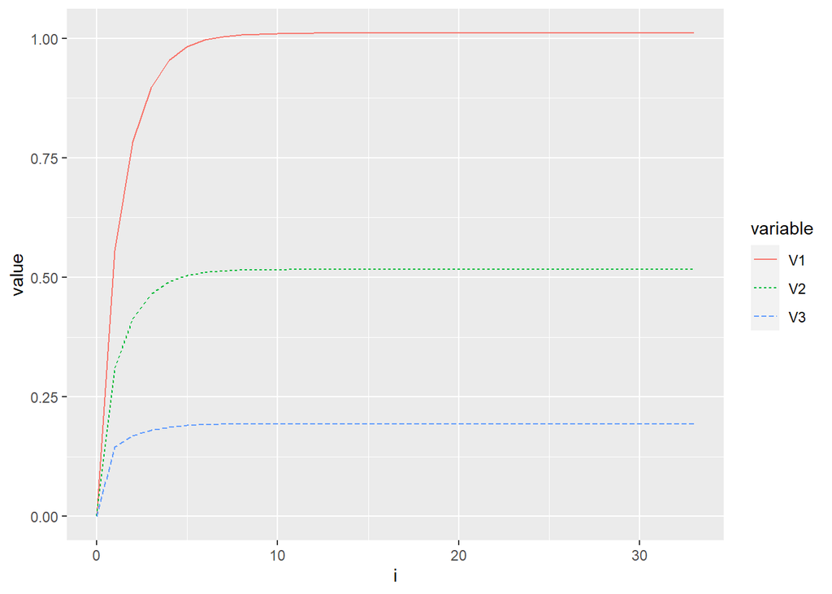

```r
plot(sd)
```

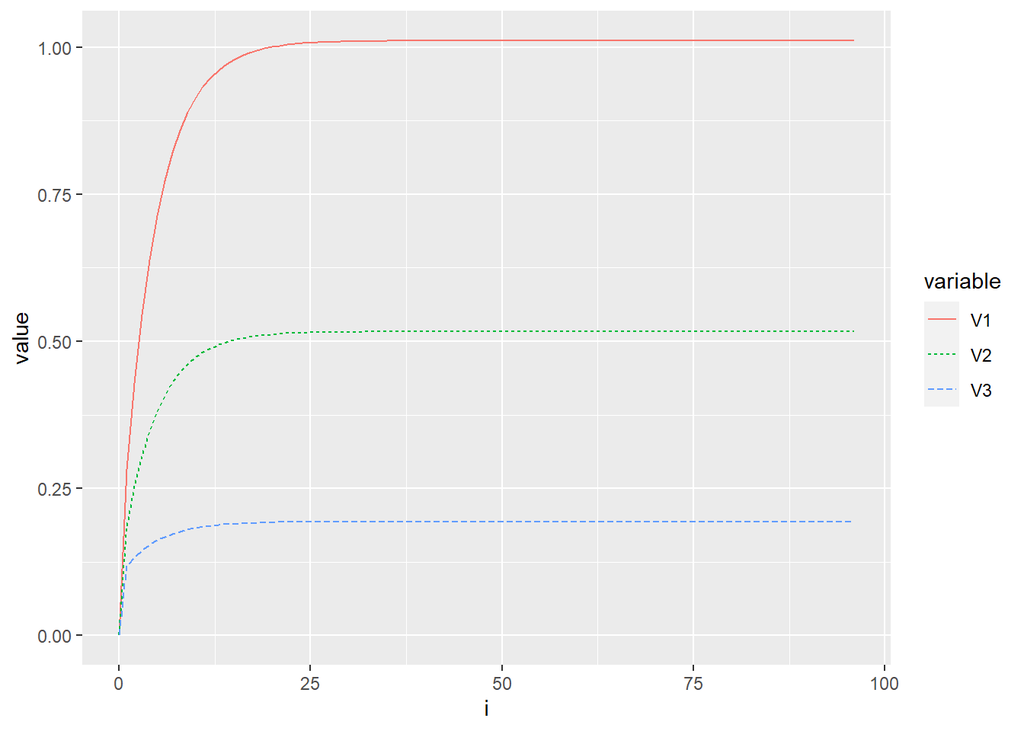

```r
plot(gd)
```

Both of the algorithm reach the convergence but the steepest descent is faster (it takes only 30 iterations!). The matrix ‘A’ inside the object generated by the function lm_gradient contains all the steps of the algorithm for further investigation.

```r
head(sd$A)
```

```
#>           [,1]      [,2]      [,3]
#> [1,] 0.5551278 0.3095927 0.1450793
#> [2,] 0.7829091 0.4137440 0.1685397
#> [3,] 0.8969060 0.4654969 0.1807254
#> [4,] 0.9539564 0.4912121 0.1870436
#> [5,] 0.9825069 0.5039890 0.1903143
#> [6,] 0.9967946 0.5103371 0.1920047
```

```r
head(gd$A)
```

```
#>           [,1]      [,2]      [,3]
#> [1,] 0.2824620 0.1840263 0.1180724
#> [2,] 0.4283826 0.2511050 0.1326700
#> [3,] 0.5450802 0.3046544 0.1444594
#> [4,] 0.6384071 0.3474032 0.1539797
#> [5,] 0.7130440 0.3815299 0.1616666
#> [6,] 0.7727337 0.4087735 0.1678725
```

Moreover, it is possible to predict new values using the method predict.

```
#>       y_pred
#> 1 -1.4301159
#> 2 -0.1986133
#> 3 -0.7966647
#> 4 -1.2008479
#> 5 -1.2796268
#> 6 -0.5204254
```

## Rcpp & R

It is possible to compare the performances of similar function written with C++ code and R code.

```r
bm <- bench::mark(gd_R = linear_optim(b, y~x1+x2, data, fun="gd"),
                  sd_R = linear_optim(b, y~x1+x2, data, fun="sd"),
                  gd_C = lm_gradient(b, y~x1+x2, data, fun="gd"),
                  sd_C = lm_gradient(b, y~x1+x2, data, fun="sd"),
                  check=FALSE)
```

[output not shown]

```r
print(bm)
```

```
#> # A tibble: 4 x 13
#>   expression      min   median `itr/sec` mem_alloc `gc/sec` n_itr  n_gc
#>   <bch:expr> <bch:tm> <bch:tm>     <dbl> <bch:byt>    <dbl> <int> <dbl>
#> 1 gd_R       187.84ms  191.3ms      5.16   306.8MB    32.7      3    19
#> 2 sd_R         6.49ms    8.3ms    118.     10.19MB    27.5     60    14
#> 3 gd_C        51.34ms  53.38ms     18.6     1.09MB     0       10     0
#> 4 sd_C          2.6ms   3.06ms    312.      1.07MB     6.00   156     3
#> # ... with 5 more variables: total_time <bch:tm>, result <list>, memory <list>,
#> #   time <list>, gc <list>
```

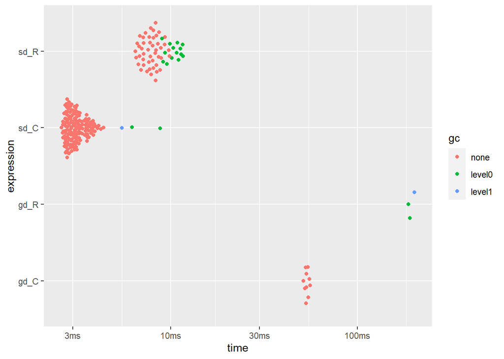

```r
ggplot2::autoplot(bm)
```

As it can be seen, C function are faster, for this reason our package is based on them.

## Cross validation

The gradient package has built-in two different methods for the cross validation: k-fold and leave-one-out. As previously descripted, both methods are available for steepest descent or gradient descent.

### K-fold

```r
gd_cv <- lm_gradient_cv(5, b=b, formula=y~x1+x2, data=data, maxit, tolerance, fun="gd", parallel = FALSE)
```

In this example we performed the k-fold cross validation with k=5. It is possible to validate the results compairing the RMSE, MAE and MedianAE error.

```r
print(gd_cv)
```

```
#>
#> 5-fold cross validation
#>
#> beta0 1.01109  beta1 0.51661  beta2 0.19381
```

```r
summary(gd_cv)
```

```
#>
#> 5-fold cross validation
#>      beta0     beta1     beta2      RMSE       MAE  MedianAE
#> 1 1.014358 0.5126494 0.2017144 1.0097489 0.8003290 0.6753147
#> 2 1.009006 0.5139953 0.1853723 1.0189839 0.8182054 0.7087281
#> 3 1.004682 0.5128643 0.1919865 0.9857097 0.7833369 0.6695402
#> 4 1.011080 0.5214173 0.2007501 1.0086868 0.7990017 0.6470258
#> 5 1.016308 0.5221406 0.1892299 1.0119014 0.8107108 0.6956769
```

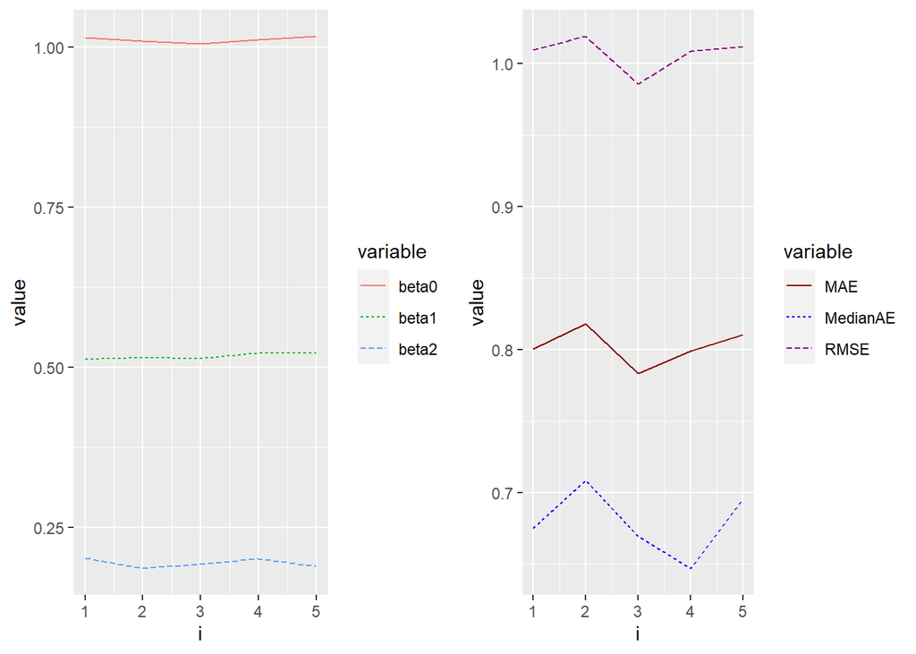

```r
plot(gd_cv)
```

### Leave-one-out

Similarly it is possbile to perform the leave-one-out cross validation with the following function:

```r
gd_looc <- lm_gradient_looc(b=b, formula=y~x1+x2, data=data, maxit, tolerance, fun="gd", parallel = FALSE)
```

and look at the results:

```r
print(gd_looc)
```

```
#>
#> 10000-fold cross validation
#>
#> beta0 -5811711525  beta1 -10766332139  beta2 16901130437
```

```r
# summary(gd_looc)
# plot(gd_looc)
```

### Parallelization

Both of the cross validation are available in parallel taking advantage of multi-core for faster computation setting the parameter parallel to TRUE.

```r
gd_cv_par <- lm_gradient_cv(5, b=b, formula=y~x1+x2, data=data, maxit, tolerance, fun="gd", parallel = TRUE)

bm1 <- bench::mark(
  parallel=lm_gradient_cv(2500, b=b, formula=y~x1+x2, data=data, maxit, tolerance, fun="sd", parallel = TRUE),
  sequential = lm_gradient_cv(2500, b=b, formula=y~x1+x2, data=data, maxit, tolerance, fun="sd", parallel = FALSE),
  check = FALSE
)

print(bm1)
```

```
#> # A tibble: 2 x 13
#>   expression    min median `itr/sec` mem_alloc `gc/sec` n_itr  n_gc total_time
#>   <bch:expr> <bch:> <bch:>     <dbl> <bch:byt>    <dbl> <int> <dbl>   <bch:tm>
#> 1 parallel    7.57s  7.57s    0.132    99.38MB    0.793     1     6      7.57s
#> 2 sequential 13.66s 13.66s    0.0732    1.66GB    5.71      1    78     13.66s
#> # ... with 4 more variables: result <list>, memory <list>, time <list>,
#> #   gc <list>
```

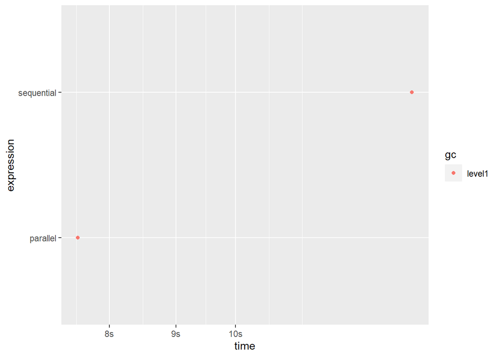

```r
ggplot2::autoplot(bm1)
```